# Planetterp: Analyzing Professors' Ratings and their Salaries

## Introduction

In 2017, students from the University of Maryland (UMD) published a website called Planetterp.com which serves as a platform for UMD students to post their personal reviews of instructors online. When choosing classes, it is useful resource for those who are signing up for classes and would like to understand if the professor would be a right fit for them. The website provides a variety of data about classes and professors. For each professor, students can see their averaged rating out of 5 stars, written reviews, grade distributions, as well as what other classes are taught by the individual.

It is important to note that these reviews are mostly anonymous and reflects a student's personal opinions. There is no objective definition of a "good" professor, or for someone who deserves a 5-star rating. These reviews may be biased. Nevertheless, they provide a window into the general student body's opinions on UMD's instructors. It is important to understand how these ratings are distributed and what factors could potentially be associated with them. Is there differences in professor ratings across departments? Is there a correlation between a professor's salary and their rating? This analysis will serve to answer these questions and more. The intention of this analysis is to determine if there are any unusual disparities among professors and departments, and to act as a stepping stone to potentially guide UMD's protocol in the future. Any findings can be used as basis to convince UMD to change hiring and salary standards to provide the best experience for students.

## Extracting and Cleaning the Data

Planetterp has a public API accesible via https://planetterp.com/api/v1. Visit this [page](https://planetterp.com/api/) for further documentation on how to use the API. Using the requests python package, a request was made to the /professors endpoint to retrieve data about UMD instructors. The API returns a maximum of 100 entries at a time in json format in alphabetical order, so it was repeatedly called until all professors were returned.

The json files were all compiled into a dataframe represented through the pandas library. There are 6 columns:

- courses - A list of courses taught by the professor/teaching assistant (TA)
- average_rating - A numerical rating out of 5, calculated by averaging all the reviews by students if any exist
- type - A string to categorize individuals as either 'professor' or 'ta'
- reviews - A list of all students' reviews
- name - The name of the professor/TA
- slug - The unique identifier used by Planetterp (typically the last name)

The data has to be cleaned up before further analysis. The data contains information on both professors and teaching assistants (TA), but for the purpose of this study, we will only focus on professors. Thus, TAs were removed from the dataframe. The study also largely focuses on a professor's ratings/reviews, so if a professor has none, then they are removed from the dataframe.

The 'courses' column extracted straight from Planetterp's API is not always accurate because it was compiled by pulling information from UMD's Schedule of Courses. It does not contain information about new courses an instructor may be teaching the current semester. Thus, if any of the new courses are mentioned in their reviews, that course is added to their existing 'courses' column.

```python
import re
import requests
import pandas as pd
import matplotlib.pyplot as plt
import numpy as np
import time
import random
import seaborn as sns
from scipy.stats import iqr
!pip install scikit-posthocs
import math
import scikit_posthocs as sp

from google.colab import drive
drive.mount('/content/drive')

# Function to extract all the professor review data on planetterp.com
def get_planetterp_df():
  df = pd.DataFrame()

  # Makes initial request
  r = requests.get('https://planetterp.com/api/v1/professors?limit=100&offset=0&reviews=true')
  offset = 0
  # Iteratively get the next 100 records of data
  while len(r.json()) != 0:
    df = pd.concat([df, pd.DataFrame(r.json())])
    offset += 100
    r = requests.get(f'https://planetterp.com/api/v1/professors?limit=100&offset={offset}&reviews=true')
  df = df[df.type == 'professor']
  df = df.dropna()

  # Get all the courses from the reviews
  def get_courses(x):
    list = []
    for entry in x:
      list.append(entry.get('course'))
    return list

  # Merge together past courses and recent courses where professors have reviews on
  df['courses'] = (df['courses'] + df.reviews.apply(get_courses)).apply(set).apply(list)
  df.name = df.name.str.lower()
  return df

# Lines commented out because the data was saved locally as a csv
#df = get_planetterp_df()
#df.to_csv('/content/drive/My Drive/CMSC320/Data/planetterp.csv')
df = pd.read_csv('/content/drive/My Drive/CMSC320/Data/planetterp.csv')
df = df.drop(['Unnamed: 0'], axis=1)
df.head()
```

|  | courses | average_rating | type | reviews | name | slug |
| --- | --- | --- | --- | --- | --- | --- |
| 0 | ['ENME202', 'ENME361', 'ENAE202', 'ENME674', '... | 5.0000 | professor | [{'professor': 'Abhijit Dasgupta', 'course': '... | abhijit dasgupta | dasgupta_abhijit |
| 1 | ['ARTH250', 'ARTH488M', 'ARTH260', 'ARTH488B',... | 2.8333 | professor | [{'professor': 'Abigail McEwen', 'course': Non... | abigail mcewen | mcewen |
| 2 | ['PHYS273', 'PHYS758E', 'PHYS405', 'PHYS275', ... | 4.0000 | professor | [{'professor': 'Abolhassan Jawahery', 'course'... | abolhassan jawahery | jawahery |
| 3 | ['STAT410', 'STAT650', 'SURV410', 'STAT700', '... | 2.7000 | professor | [{'professor': 'Abram Kagan', 'course': 'STAT4... | abram kagan | kagan |
| 4 | ['ENGL101S', 'ENGL243', 'ENGL101', 'PHSC497'] | 5.0000 | professor | [{'professor': 'Adam Binkley', 'course': 'ENGL... | adam binkley | binkley |

In this study, we would like to investigate if there is any patterns in professors' salaries, and to get this data, we can use the Diamondback (DBK). The DBK is a newspaper lead by UMD students, and every year, they recieve data from the school reporting the salaries of school faculty. The newspaper has a publically available API at https://api.dbknews.com/ where the salary data is available at the salary endpoint. Documentation of how to use this API is found [here](https://api.dbknews.com/docs/). Unfortunately, the data is split into pages, where each page only holds 10 entries of data, and there are 1000+ pages per year. In order to not overload the servers and unintentionally initiate a DOS attack, a random wait time between 5 and 10 seconds is integrated between each request. Read more about common pratices to web scrape without disrupting service [here](https://www.diggernaut.com/blog/how-to-avoid-getting-detected-during-web-scraping/).

```python
# Make a pandas dataframe containing all the professors' salary data for that year
def get_dbk_df(year):
  df_salary = []

  # Form the initial request
  r = requests.get(f'https://api.dbknews.com/salary/year/{year}?search=&sortby=salary&order=desc&page=1')
  page = 1

  # Iteratively getting each page for the year (while waiting 5-10 seconds between each call)
  while len(r.json()['data']) != 0:
    df_salary.extend(r.json()['data'])
    page += 1
    r = requests.get(f'https://api.dbknews.com/salary/year/{year}?search=&sortby=salary&order=desc&page={page}')
    time.sleep(random.randint(5,10))

  # Turn data into a pandas dataframe
  df_salary = pd.DataFrame(df_salary)

  # Function to format the name into 'firstname lastname' (all lowercase)
  def reformat_name(x):
    reg = re.match("^(.+),\s([^\s]+)", x)
    return (reg.groups()[1] + " " + reg.groups()[0]).lower()

  df_salary['Division'] = df_salary['Division'].str.replace("\n", " ")  # Clean data of any '\n'
  df_salary['Department'] = df_salary['Department'].str.replace("\n", " ")
  df_salary['Title'] = df_salary['Title'].str.replace("\n", " ")
  df_salary['Employee'] = df_salary['Employee'].apply(reformat_name)  # Reformat names
  df_salary['Salary'] = df_salary['Salary'].apply(lambda x: float(x[1:].replace(",","")))   # Turn salary into numbers

  # Save the data frame as a csv for convenience and speed
  df_salary.to_csv(f'/content/drive/My Drive/CMSC320/Data/dbk_salary_{year}.csv')
  return df_salary

# Commented out because data is now saved locally; uncomment to get data for the first time
#df_salary_2022 = get_dbk_df(2022)
#df_salary_2021 = get_dbk_df(2021)
#df_salary_2020 = get_dbk_df(2020)
#df_salary_2019 = get_dbk_df(2019)
#df_salary_2018 = get_dbk_df(2018)
#df_salary_2017 = get_dbk_df(2017)
#df_salary_2016 = get_dbk_df(2016)
#df_salary_2015 = get_dbk_df(2015)
#df_salary_2014 = get_dbk_df(2014)
#df_salary_2013 = get_dbk_df(2013)

# Read from csv after pulling from the api and saving the data locally
dbk_salary_2022 = pd.read_csv(f'/content/drive/My Drive/CMSC320/Data/dbk_salary_2022.csv')
dbk_salary_2021 = pd.read_csv(f'/content/drive/My Drive/CMSC320/Data/dbk_salary_2021.csv')
dbk_salary_2020 = pd.read_csv(f'/content/drive/My Drive/CMSC320/Data/dbk_salary_2020.csv')
dbk_salary_2019 = pd.read_csv(f'/content/drive/My Drive/CMSC320/Data/dbk_salary_2019.csv')
dbk_salary_2018 = pd.read_csv(f'/content/drive/My Drive/CMSC320/Data/dbk_salary_2018.csv')
dbk_salary_2017 = pd.read_csv(f'/content/drive/My Drive/CMSC320/Data/dbk_salary_2017.csv')
dbk_salary_2016 = pd.read_csv(f'/content/drive/My Drive/CMSC320/Data/dbk_salary_2016.csv')
dbk_salary_2015 = pd.read_csv(f'/content/drive/My Drive/CMSC320/Data/dbk_salary_2015.csv')
dbk_salary_2014 = pd.read_csv(f'/content/drive/My Drive/CMSC320/Data/dbk_salary_2014.csv')
dbk_salary_2013 = pd.read_csv(f'/content/drive/My Drive/CMSC320/Data/dbk_salary_2013.csv')

dbk_salaries = [dbk_salary_2013, dbk_salary_2014, dbk_salary_2015, dbk_salary_2016, dbk_salary_2017, dbk_salary_2018, dbk_salary_2019,
                dbk_salary_2020, dbk_salary_2021, dbk_salary_2022]

# Resolving the format after reading and saving as a csv
for salary in dbk_salaries:
  salary.drop(['Unnamed: 0'], axis=1, inplace=True)

dbk_salary_2022.head()
```

|  | Division | Department | Title | Employee | Salary |
| --- | --- | --- | --- | --- | --- |
| 0 | Office of the President | PRES-President's Office | President | darryll pines | 791966.25 |
| 1 | Office of the President | PRES-Intercollegiate Athletics | Head Coach | mark turgeon | 725000.00 |
| 2 | Office of the President | PRES-Intercollegiate Athletics | Director of Athletics | damon evans | 675649.56 |
| 3 | Office of the President | PRES-Intercollegiate Athletics | Head Coach BB | brenda frese | 666600.00 |
| 4 | Office of the President | PRES-Intercollegiate Athletics | Asst Coach | brian stewart | 550000.00 |

## Data Management

### Adding new columns

The base data is now collected, but it would be helpful to reformat the data frames by adding new columns to make analysis easier in the long run. For the planetterp.com dataframe, we can add an additional column to keep track of the number of reviews an individual has.

```python
import ast

# Takes in a list of objects and returns only the review portion of it
def extract_reviews(row):
    list = []
    for entry in ast.literal_eval(row.reviews):
      list.append(entry.get('review'))
    return len(list)

# Extracts the number of reviews for each professor
df['num_reviews'] = df.apply(extract_reviews, axis=1)
```

For the DBK salary data, the titles of the faculty members are stored as a single string. This string can be parsed to separate out the individual titles for each employee.

```python
for salary in dbk_salaries:
  salary['Title'] = salary['Title'].str.split(r"\s+(?:&|and)\s+")     # Turns the title string into a list

dbk_salary_2022.head()
```

|  | Division | Department | Title | Employee | Salary |
| --- | --- | --- | --- | --- | --- |
| 0 | Office of the President | PRES-President's Office | [President] | darryll pines | 791966.25 |
| 1 | Office of the President | PRES-Intercollegiate Athletics | [Head Coach] | mark turgeon | 725000.00 |
| 2 | Office of the President | PRES-Intercollegiate Athletics | [Director of Athletics] | damon evans | 675649.56 |
| 3 | Office of the President | PRES-Intercollegiate Athletics | [Head Coach BB] | brenda frese | 666600.00 |
| 4 | Office of the President | PRES-Intercollegiate Athletics | [Asst Coach] | brian stewart | 550000.00 |

### Creating new data frames

With this study, we are hoping to eventually analyze the professor ratings and salaries with respect with each other, so it would be much easier to merge the two data frames together. Saving this as a separate data frame will save some time from constantly doing look-ups.

Merging the two data frames would be a simple procedure if only the professors at UMD never changed, but that is not the case. Professors come and go every year, thus there are some professors who are present in the planetterp.com data frame, but are only listed in the DBK salary report in previous years depending on when they taught at UMD.

To resolve this, I created a function that looks back at time to find records of each professor in the DBK salary reports. It only looks back as far as it needs to so it will only pull the most recent records of the professor. These records would then be added to the corresponding entry in the planetterp data frame.

```python
# Add the years so we know what year the salary was pulled from
for i in range(len(dbk_salaries)):
  dbk_salaries[i]['year'] = 2013+i

# Matches a professor to their most recent salary information
def get_most_recent_info(row):
  name = row['name']
  salary = np.NaN     # default salary value is NaN
  index = len(dbk_salaries) - 1
  year = np.NaN
  while salary is np.NaN and index >= 0:    # Loops from 2022 to 2013 salary data until an entry with their name is found
    match = dbk_salaries[index][dbk_salaries[index]['Employee'] == name]
    if len(match.index) >0:
      salary = match.iloc[0]['Salary']
      year = 2013+index
      return salary, year, match.iloc[0]['Department'], match.iloc[0]['Title']      # Returns their data if match is found
    index -= 1
  return salary, year, np.NaN, np.NaN   # Otherwise, return default values of NaN

# Creates a new data frame containing professors' ratings along with their most recent salary, department, and titles
merged_df = df.copy()
merged_df[['salary', 'salary_year', 'department', 'title']] = df.apply(get_most_recent_info, axis=1, result_type='expand')
```

## Exploratory Data Analysis

We now have the data in a easily digestible format for analysis. Before doing any statistical tests, we should explore our data to see if we can find any interesting shapes and/or patterns. This is an important step to understanding our data and gaining insight on what questions should be asked. Knowing the shape of our data will also aid us in doing hypothetical tests. Let's first explore the professors ratings.

### Planetterp.com Data

#### What does the distribution of average ratings look like?

We should first look at a plot of all the ratings on planetterp.com. In the graph below, the x axis represents a professor's average rating. It ranges from 1 to 5, 1 being the worst and 5 being the best for a professor. The y axis represents the number of individuals who fall within each bin.

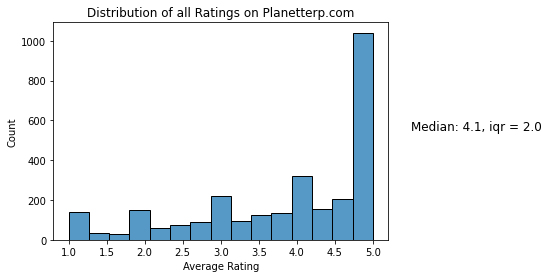

```python
sns.histplot(data=df, x='average_rating')
plt.title("Distribution of all Ratings on Planetterp.com")
plt.xlabel("Average Rating")
plt.text(5.5, 550, f'Median: {np.median(df["average_rating"])}, iqr = {iqr(df["average_rating"])}', fontsize = 12)
```

Note that this graph was created by plotting the data of everyone listed on plannetterp.com with reviews. It is important to know that anyone who has taught/lead a class may find their name on this website, including lecturers, coordinators, and TAs. Not everyone holds the same level of responsibilities, so to control for this, we will filter strictly by those with the 'Professor' title.

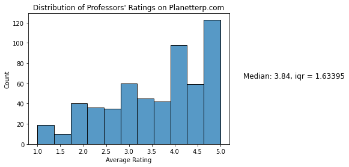

```python
# Looks for people with 'Professor' as their title (or 'Prof' for short)
def prof_filter(title):
  if (type(title) != float):
    return 'Prof' in title or 'Professor' in title
  return False
merged_df_prof = merged_df[merged_df['title'].apply(prof_filter)]   # Creates a new data frame containing only professors

# Graphs the ratings of only professors
sns.histplot(data=merged_df_prof, x='average_rating')
plt.title("Distribution of Professors' Ratings on Planetterp.com")
plt.xlabel("Average Rating")
plt.text(5.5, 65, f'Median: {np.median(merged_df_prof["average_rating"])}, iqr = {iqr(merged_df_prof["average_rating"])}', fontsize = 12)
```

The distribution is now much more evenly distributed along the range of possible all possible ratings. The median is now 3.84, and the interquartile range was lowered to 1.63. Higher ratings are still more common than lower ratings, but now there is not a disproporationately high number of 5 star ratings.

Notice that there are peaks at each whole number interval (ie. 1.0, 2.0, 3.0, etc.). This is because many professors may have only one review on their profile, leading to the average being a whole number. What would the distribution look like if we were to look at professors with more than 1 review? 2 reviews? 5 reviews?

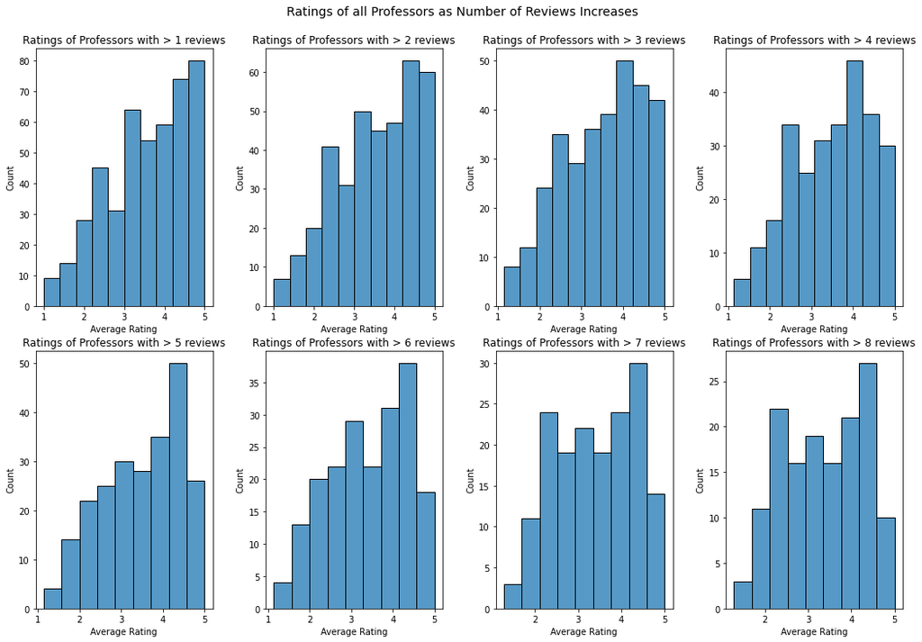

```python
fig, axes = plt.subplots(2, 4, figsize=(15, 10))
fig.tight_layout(pad=3)

fig.suptitle("Ratings of all Professors as Number of Reviews Increases", y=1.02, fontsize=14)

min_reviews = 1
# For each plot, graph the distribution of average ratings for professors with increasing number of ratings
for i in range(2):
  for j in range(4):
    sns.histplot(data=merged_df_prof[merged_df_prof['num_reviews']>min_reviews], x="average_rating", ax=axes[i][j])
    axes[i][j].set_title(f'Ratings of Professors with > {min_reviews} reviews')
    axes[i][j].set_xlabel("Average Rating")
    min_reviews += 1
```

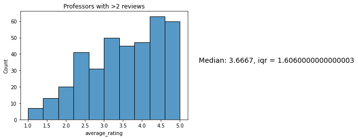

```python
# Let's focus on the plot >2 reviews, and see what the median and spread is
sns.histplot(data=merged_df_prof[merged_df_prof['num_reviews'] > 2], x="average_rating").set(title='Professors with >2 reviews')
plt.text(5.5, 35, f"Median: {np.median(merged_df_prof[merged_df_prof['num_reviews'] > 2]['average_rating'])}, iqr = {iqr(merged_df_prof[merged_df_prof['num_reviews'] > 2]['average_rating'])}", fontsize = 14)
```

In the above plot, we have several graphs in a row showing the distribution of average ratings among professors with more and more reviews. In the first plot, we are graphing the distribution of ratings among professors with more than 1 review, while the last plot is doing the same but among professors with more than 8 reviews. As the number of reviews increase, you can see that the distributions are becoming more and more normal. The peaks also disappear. Towards the end, the distributions start looking more symmetrical, and the center of the data is moving more towards 3.

There can be many speculations as to why this could be. Perhaps there are a lot of 5 star professors because there are only a handful of students who are passionate enough to write a review for new professors, especially if they had a very positive experience. This is also known as selection bias, which occurs if respondants have a choice in giving away their data. This could potentially be the case here because not every student is obliged to give their opinion. Another possible explanation is that some professors may have a teaching style that people either agree or disagree with. These professors may be a bit controversial, conjuring up mixed reviews in large sums.

#### How do ratings differ among different departments?

We know what the overall distribution looks like, but what if it were separated by departments? Do departments have different distributions of professor's ratings? Are there departments that tend to have higher ratings? Are there departments with very low ratings? This can help shed some light on which departments need some improvment in regards to teaching students.

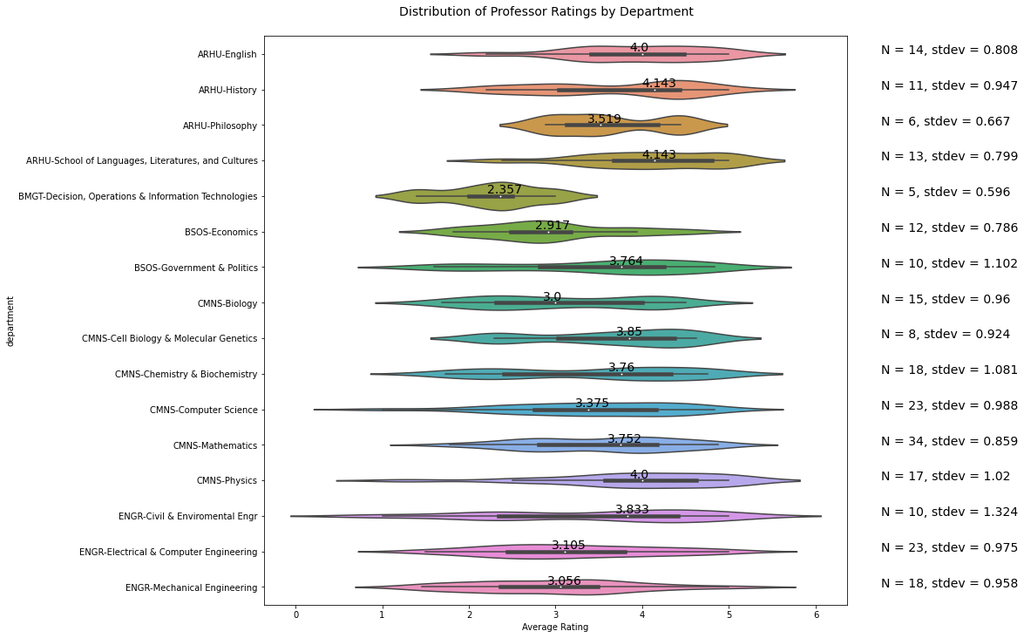

```python
fig, ax = plt.subplots(1, 1, figsize=(12, 12))

# Filter to only grab faculty members who are a professor
def prof_filter(title):
  if (type(title) != float):
    return 'Prof' in title or 'Professor' in title
  return False
merged_df_prof = merged_df[merged_df['title'].apply(prof_filter)]

# Select departments where there are more than 10 professors with ratings
departments_pt = merged_df_prof.groupby('department').size() > 10
departments_pt = departments_pt.loc[departments_pt.values == True].reset_index()['department'].tolist()
merged_df_prof_large = merged_df_prof[merged_df_prof['department'].isin(departments_pt)]

# Graph ratings for professors with over 2 review by department
sns.violinplot(data=merged_df_prof_large[merged_df_prof_large['num_reviews'] > 2], x="average_rating", y="department", ax=ax, order=sorted(departments_pt), bw=.4)

medians = merged_df_prof_large[(merged_df_prof_large['num_reviews'] > 2)].groupby(['department'])['average_rating'].median()
sizes = merged_df_prof_large[(merged_df_prof_large['num_reviews'] > 2)].groupby(['department'])['average_rating'].size()
stdevs = merged_df_prof_large[(merged_df_prof_large['num_reviews'] > 2)].groupby(['department'])['average_rating'].std()

# Plot the medians
for i, v in enumerate(medians):
    plt.text((v - 0.15), (i-0.07), str(round(v, 3)), fontsize = 14)

# Plot the sample size and standard deviation
for i, v in enumerate(sizes):
    plt.text(6.75, i, f'N = {str(round(v, 3))}, stdev = {round(stdevs[i], 3)}', fontsize = 14)

fig.suptitle("Distribution of Professor Ratings by Department", y=0.92, fontsize=14)
plt.xlabel("Average Rating")
```

Above is a graph showing the distribution of professors' ratings for large departments (large defined as having more than 10 professors with ratings on planetterp.com). This number was chosen by trial and error, trying to get the enough departments to analyze, but not too many. It may seem like there are a lot of departments here to consider, but this is intentional. Some of the departments belong to the same school. We can now analyze whether departments in the same school are similar, and examine the difference beteen different schools.

I also narrowed down the ratings to only include the ratings of professors with more than 2 review to reduce the amount of noise in the distributions. This would control for the unusual peaks we saw earlier. It would also simply be unfair to believe that 1 or 2 anonymous review is enough to accurately reflect all students' opinions of a professor's teaching. Ideally, we would want as many reviews per professor as possible, but planetterp.com is a fairly new website that will need more time to collect more data.

If we were to look at department alone, we can say that there is a lot of variety. Some departments tend to have higher ratings >4, for example, ARHU-History and Languages, Literatures, and Cultures, but there are many more which fall in the 3 star ranges instead. A noticeable one is the BMGT-Decisions, Operations & Information Technologies (DO&IT) department. They have a median rating of 2.357, which is much lower compared to other departments depicted here. Not all departments have the same spread either. Some have very low standard deviations, like DO&IT at 0.596 and Philosophy at 0.667, while Civil & Environmental Engineering (CEE) is at 1.324. This could be due to some departments having more professors in them, but there exists departments with more members than CEE but lower standard deviations.

Now, let's focus on schools. There are 5 main schools present in the plot above: ARHU (Arts and Humanities), BMGT (Business and Management), BSOS (Behaviorial and Social Sciences), CMNS (Computer, Mathematical, and Natural Sciences), and ENGR (Engineering). There are some general patterns within schools that seems to be consistent. ARHU tends to have higher ratings, with very little variation. CMNS and ENGR are very large schools, so their median tends to fall within the average and they have large standard deviations.

### Salary Data

We have explored the planetterp.com ratings and found some facts about the distribution of professors ratings and how they look between different departments. Now, let us do the same for the salary data compiled by The Diamondback.

#### What does the distribution of salaries look like?

Before any intricate analysis, we should understand what kind of distribution the faculty's salaries falls along for the year 2022.

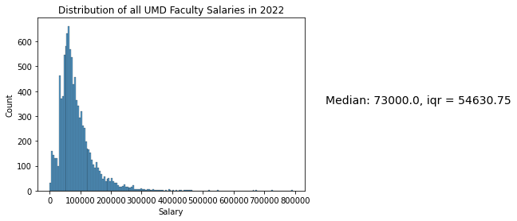

```python
sns.histplot(data=dbk_salary_2022, x='Salary')
plt.title("Distribution of all UMD Faculty Salaries in 2022")
plt.text(900000, 350, f'Median: {np.median(dbk_salary_2022["Salary"])}, iqr = {iqr(dbk_salary_2022["Salary"])}', fontsize = 14)
```

The graph above displays the distribution of employee salaries in 2022. The median salary is \$73,000 with an interquartile range of \$54,630.75. It is extremely right-skewed, following a power law distribution (which presents the idea of the rich getting richer). A majority of individuals have a salary that falls in the bin from \$0 to \$100,000, but there are some individuals who have salaries of almost $800,000. Who are these individiuals?

```python
dbk_salary_2022[dbk_salary_2022['Salary'] > 600000]
```

|  | Division | Department | Title | Employee | Salary | year |
| --- | --- | --- | --- | --- | --- | --- |
| 0 | Office of the President | PRES-President's Office | [President] | darryll pines | 791966.25 | 2022 |
| 1 | Office of the President | PRES-Intercollegiate Athletics | [Head Coach] | mark turgeon | 725000.00 | 2022 |
| 2 | Office of the President | PRES-Intercollegiate Athletics | [Director of Athletics] | damon evans | 675649.56 | 2022 |
| 3 | Office of the President | PRES-Intercollegiate Athletics | [Head Coach BB] | brenda frese | 666600.00 | 2022 |

It comes as no surprise that the individuals that earned the most during the 2022 year are the President and the higher-up sport faculty members. It is known that UMD invests highly on their sports team, but these numbers inflate our distributions. What if we were to only examine those with a professor title?

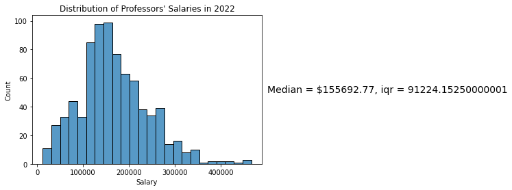

```python
dbk_salary_2022_prof = dbk_salary_2022[dbk_salary_2022['Title'].apply(lambda x: 'Prof' in x or 'Professor' in x)]
sns.histplot(data=dbk_salary_2022_prof, x='Salary')
median = dbk_salary_2022_prof['Salary'].median()
plt.title("Distribution of Professors' Salaries in 2022")
plt.text(500000, 50, f'Median = ${round(median, 3)}, iqr = {iqr(dbk_salary_2022_prof["Salary"])}', fontsize = 14)
```

The distribution becomes much more normal looking. The median salary of professors is \$155,692.77 with an interquartile range of \$91,224.15. Note that the interquartile range has only increased because a lot of the data was filtered out.

It is roughly symmetrical with a slight right skew, but much less than the previous graph. The average salary is about $155,000, but there is still a lot of variation, with some professors making over \$400,000 while some not making over \$50,000. The extreme low end of the spectrum could be explained by professors who do not work primarily at UMD.

### How does salary differ among departments?

We have the distribution for all professors' salaries, so now we can try to delve a little deeper and see how it changes based on departments. Will all departments have the same distribution? Are there some that are typically paid more than others?

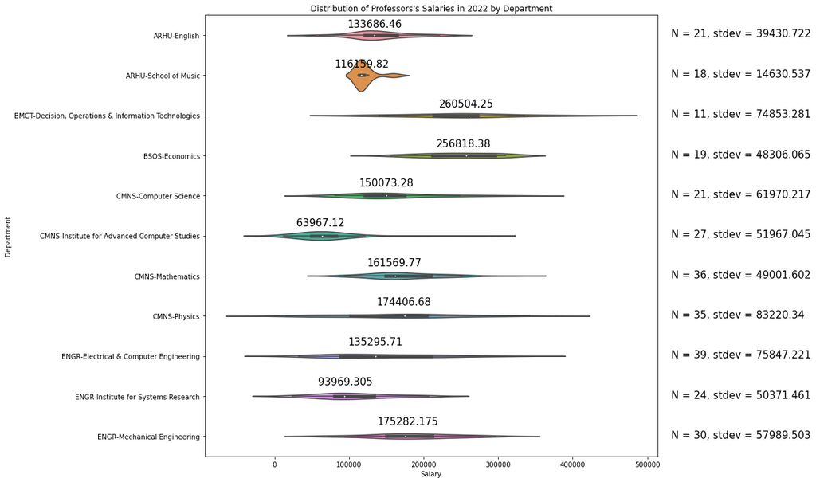

```python
fig, ax = plt.subplots(1, 1, figsize=(12, 12))

# Search for departments with size > 17
departments = dbk_salary_2022_prof.groupby('Department').size() > 17
departments = departments.loc[departments.values == True].reset_index()['Department'].tolist()
departments.append("BMGT-Decision, Operations & Information Technologies")    # Explicitly add in this department for analysis
dbk_salary_2022_prof_large = dbk_salary_2022_prof[dbk_salary_2022_prof['Department'].isin(departments)]
sns.violinplot(data=dbk_salary_2022_prof_large, x="Salary", y="Department", ax=ax, order=sorted(departments), scale='area')

medians = dbk_salary_2022_prof_large.groupby(['Department'])['Salary'].median()
sizes = dbk_salary_2022_prof_large.groupby(['Department'])['Salary'].size()
stdevs = dbk_salary_2022_prof_large.groupby(['Department'])['Salary'].std()

plt.title("Distribution of Professors's Salaries in 2022 by Department")
# Plot the medians
for i, v in enumerate(medians):
    plt.text(v * 0.0000016 + 0.1, i * -0.09 + 0.972, str(round(v, 3)), fontsize = 15, transform = ax.transAxes)

# Plot the sizes and standard deviation
for i, v in enumerate(sizes):
    plt.text(1.03, i * -0.091 + 0.9505, f'N = {str(round(v, 3))}, stdev = {round(stdevs[i], 3)}', fontsize = 15, transform = ax.transAxes)
```

The graph above covers the salary distribution among some of the major departments. Major is defined as having more than 17 professors in the department. DO&IT was explicitly added to the plot because it leads to some interesting observations which I will discuss soon.

As seen in the plot above, none of the departments above are exactly like another. The averages by each department ranges from \$60k to \$260k, and the spreads are also wildly different. Some departments to point out are Music and English. They both belong to the ARHU school, and their median salaries are \$116k and \$133k respectively. Both of their averages are below the \$155,000 overall median. They also have an unusually small standard deviation compared to other departments (\$14k for Music and \$39k for English). Something to note is that if you remember from previous graphs, these departments have tend to have higher ratings on planetterp.com than other departments. This is in contrast to DO&IT, which tends to have lower ratings on plantetterp.com, but has a higher median salary than any other department in the plot (\$260k).

Another point of interest is that Computer Science professors make \$150k on average, while those who work for the Institute for Advanced Computer Science only make an average of \$64k. This may be due to the fact that the Institute for Advanced Computer Science primarily focuses on research.

## Hypothesis Tests

After analyzing the data, we are left with a lot of questions with not many answers. Planetterp.com data is incomplete at best; there are many professors who do not have reviews, and of the ones that do have reviews, many do not have enough to reliably gauge the quality of their teaching style. While I did pull all the data that planetterp.com has to offer, what I really have is simply a sample of student's opinions. In order to answer any questions with a quantifiable amount of certainty, I have to rely on hypothesis tests. Hypothesis tests enable us to calculate how confident we can be to make certain statements about the population through only using sample data. The challenge is in determining how much of the variance we are seeing in the sample is attributable to random sampling error versus actual differences in the population. That is why it is essential to run a statistical test whenever trying to draw a conclusion from the planetterp.com data.

In contrast, the salary and department data I pulled from The Diamondback holds the information of all faculty at UMD for the particular year. In other words, we are dealing directly with population data, not sample data. There is no need to run hypotheses tests to make statements about the salary.

Let's try to answer the following questions:

- Are the professor ratings between different departments statistically different?
- Is there a linear relationship between professor's salaries and their ratings on planetterp.com?

### Are the professor ratings between different departments statistically different?

If you were to recall, we graphed professors' average ratings by department, and some departments turned out to have higher average ratings than others in our data. The median professor rating for ARHU-School of Languages, Literaures, and Cultures is 4.143, while the median for DO&IT is 2.357. But is this enough basis to claim that these departments truly have different average professor ratings? Or is it simply due to sampling error?

We have several independent samples of data (one for each department), and we would like to determine if they have the same average. [This](https://towardsdatascience.com/hypothesis-tests-explained-8a070636bd28) is a helpful flowchart that can help you decide on which hypothesis test you should use. The most common test for this kind of analysis is the analysis of variance (ANOVA) test, however, our data does not meet some of the assumptions required to use this test. One of the assumptions is that all of the samples follow a normal distribution. This does not hold true for our data. We already have a violin plot, but to confirm this, we can use histograms.

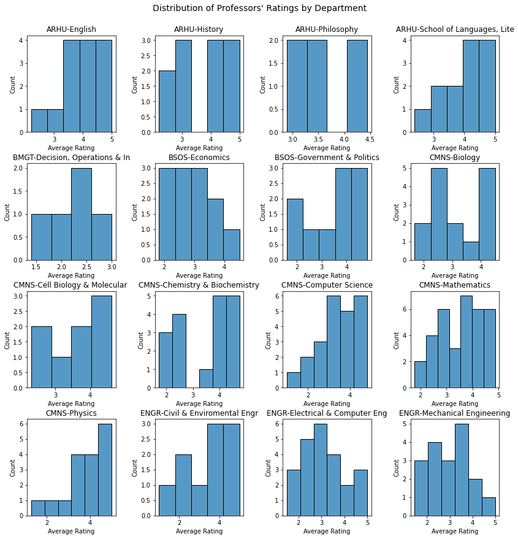

```python
fig, axes = plt.subplots(4, 4, figsize=(12,12))
fig.tight_layout(pad=3)

# For each plot, graph the distribution of average ratings for professors by department
for i in range(4):
  for j in range(4):
    sns.histplot(data=merged_df_prof_large[(merged_df_prof_large['num_reviews'] > 2) & (merged_df_prof_large['department']==departments_pt[i*4+j])], x="average_rating", ax=axes[i][j])
    axes[i][j].set_title(departments_pt[i*4 + j][:30])
    axes[i][j].set_xlabel("Average Rating")

fig.suptitle("Distribution of Professors' Ratings by Department", y=1.02, fontsize=14)
```

The plots above shows the distribution of professors' average ratings for each of the major departments. Notice that not many of them are normally distributed; the distributions somestimes appear uniform, bimodal, and/or right-skewed. They do not look normal, nor do we have a large enough sample size per sample to rely on the central limit theorem, so it would be ill-advised to perform an ANOVA test. Instead, we can do the non-parametric version of it: the [Kruskal-Wallis Test](https://statistics.laerd.com/spss-tutorials/kruskal-wallis-h-test-using-spss-statistics.php). There are 4 assumptions that need to be checked in order to use this test accurately:

1. The dependent variable is ordinal or continuous - This is true because average rating can be any number from 1 to 5.
2. The independent variable is a 2 or more independent categories - This is true because our independent variable is departments, which are independent of each other because they are separate facilities in UMD. We also have much more than 2 departments in UMD.
3. The observations are independent - This is true because it would not make sense for the rating of one professor to affect the rating of another professor unless there were very unusual circumstances.
4. If the samples are similarly distributed, we can test the medians of the samples. Otherwise, the Kruskal-Wallis test will primarily be a test of dominance - As seen in the histograms above, the departments do not have similarly shaped distributions, so it would have to be the latter.

A test of dominance will test whether there exists a group such that its values tend to be higher than other groups by probability. If you want to learn more, check out stochastic dominance (https://en.wikipedia.org/wiki/Stochastic_dominance).

- Null hypothesis: There exists no such group.
- Alternative hypothesis: There exists such a group.

We will use 0.05 as our level of significance for all our hypothesis tests.

```python
from scipy.stats import kruskal

# Getting all the departments in one array
grouped_ratings = []
for department in departments_pt:
  grouped_ratings.append(merged_df_prof_large[(merged_df_prof_large['num_reviews'] > 2) & (merged_df_prof_large['department'] == department)]['average_rating'])

# Running the Kruskal-Wallis test
kruskal(*grouped_ratings)
```

```
KruskalResult(statistic=30.76761845183882, pvalue=0.009435509707798863)
```

The p-value is 0.00944, which is less than 0.05. This means that we have enough evidence to conclude that there is a department that tends to get higher ratings than another. How do we find out which department this is? We can run a post hoc test.

We can run the Dunn test, which typically follows a Kruskal-Wallis test. It performs multiple comparisons between all possible pairs of samples, and tells us which groups are different from each other. Read more about the Dunn test [here](https://journals.sagepub.com/doi/pdf/10.1177/1536867X1501500117#:~:text=Dunn's%20test%20is%20the%20appropriate%20procedure%20following%20a%20Kruskal%E2%80%93Wallis,framework%20of%20the%20hypothesis%20test.).

```python
sp.posthoc_dunn(grouped_ratings, p_adjust = 'bonferroni')
```

|  | 1 | 2 | 3 | 4 | 5 | 6 | 7 | 8 | 9 | 10 | 11 | 12 | 13 | 14 | 15 | 16 |
| --- | --- | --- | --- | --- | --- | --- | --- | --- | --- | --- | --- | --- | --- | --- | --- | --- |
| 1 | 1.000000 | 1.0 | 1.0 | 1.000000 | 0.219098 | 1.000000 | 1.0 | 1.0 | 1.0 | 1.0 | 1.0 | 1.0 | 1.000000 | 1.0 | 1.0 | 0.973825 |
| 2 | 1.000000 | 1.0 | 1.0 | 1.000000 | 1.000000 | 1.000000 | 1.0 | 1.0 | 1.0 | 1.0 | 1.0 | 1.0 | 1.000000 | 1.0 | 1.0 | 1.000000 |
| 3 | 1.000000 | 1.0 | 1.0 | 1.000000 | 1.000000 | 1.000000 | 1.0 | 1.0 | 1.0 | 1.0 | 1.0 | 1.0 | 1.000000 | 1.0 | 1.0 | 1.000000 |
| 4 | 1.000000 | 1.0 | 1.0 | 1.000000 | 0.090482 | 0.478187 | 1.0 | 1.0 | 1.0 | 1.0 | 1.0 | 1.0 | 1.000000 | 1.0 | 1.0 | 0.322949 |
| 5 | 0.219098 | 1.0 | 1.0 | 0.090482 | 1.000000 | 1.000000 | 1.0 | 1.0 | 1.0 | 1.0 | 1.0 | 1.0 | 0.166142 | 1.0 | 1.0 | 1.000000 |
| 6 | 1.000000 | 1.0 | 1.0 | 0.478187 | 1.000000 | 1.000000 | 1.0 | 1.0 | 1.0 | 1.0 | 1.0 | 1.0 | 0.910820 | 1.0 | 1.0 | 1.000000 |
| 7 | 1.000000 | 1.0 | 1.0 | 1.000000 | 1.000000 | 1.000000 | 1.0 | 1.0 | 1.0 | 1.0 | 1.0 | 1.0 | 1.000000 | 1.0 | 1.0 | 1.000000 |
| 8 | 1.000000 | 1.0 | 1.0 | 1.000000 | 1.000000 | 1.000000 | 1.0 | 1.0 | 1.0 | 1.0 | 1.0 | 1.0 | 1.000000 | 1.0 | 1.0 | 1.000000 |
| 9 | 1.000000 | 1.0 | 1.0 | 1.000000 | 1.000000 | 1.000000 | 1.0 | 1.0 | 1.0 | 1.0 | 1.0 | 1.0 | 1.000000 | 1.0 | 1.0 | 1.000000 |
| 10 | 1.000000 | 1.0 | 1.0 | 1.000000 | 1.000000 | 1.000000 | 1.0 | 1.0 | 1.0 | 1.0 | 1.0 | 1.0 | 1.000000 | 1.0 | 1.0 | 1.000000 |
| 11 | 1.000000 | 1.0 | 1.0 | 1.000000 | 1.000000 | 1.000000 | 1.0 | 1.0 | 1.0 | 1.0 | 1.0 | 1.0 | 1.000000 | 1.0 | 1.0 | 1.000000 |
| 12 | 1.000000 | 1.0 | 1.0 | 1.000000 | 1.000000 | 1.000000 | 1.0 | 1.0 | 1.0 | 1.0 | 1.0 | 1.0 | 1.000000 | 1.0 | 1.0 | 1.000000 |
| 13 | 1.000000 | 1.0 | 1.0 | 1.000000 | 0.166142 | 0.910820 | 1.0 | 1.0 | 1.0 | 1.0 | 1.0 | 1.0 | 1.000000 | 1.0 | 1.0 | 0.617396 |
| 14 | 1.000000 | 1.0 | 1.0 | 1.000000 | 1.000000 | 1.000000 | 1.0 | 1.0 | 1.0 | 1.0 | 1.0 | 1.0 | 1.000000 | 1.0 | 1.0 | 1.000000 |
| 15 | 1.000000 | 1.0 | 1.0 | 1.000000 | 1.000000 | 1.000000 | 1.0 | 1.0 | 1.0 | 1.0 | 1.0 | 1.0 | 1.000000 | 1.0 | 1.0 | 1.000000 |
| 16 | 0.973825 | 1.0 | 1.0 | 0.322949 | 1.000000 | 1.000000 | 1.0 | 1.0 | 1.0 | 1.0 | 1.0 | 1.0 | 0.617396 | 1.0 | 1.0 | 1.000000 |

### Is there a linear relationship between professor's salaries and their ratings on planetterp.com?

It would be interesting to see whether or not a professor's rating is correlated to their salary. Are 'good' professors well-compensated? How about vice-versa? This could spur on many other potential questions, such as, are teachers more motivated with a higher salary? Of course, such questions are out of scope with the current data and level of statistical analysis we are doing, but it poses potential for future investigations if there is indeed a correlation. For now, I will be only looking at 2022 data because inflation over time could affect how we see salaries.

```
                            OLS Regression Results
==============================================================================
Dep. Variable:                 salary   R-squared:                       0.002
Model:                            OLS   Adj. R-squared:                 -0.001
Method:                 Least Squares   F-statistic:                    0.6155
Date:                Fri, 02 Dec 2022   Prob (F-statistic):              0.433
Time:                        20:44:15   Log-Likelihood:                -3547.0
No. Observations:                 287   AIC:                             7098.
Df Residuals:                     285   BIC:                             7105.
Df Model:                           1
Covariance Type:            nonrobust
==================================================================================
                     coef    std err          t      P>|t|      [0.025      0.975]
----------------------------------------------------------------------------------
Intercept       1.822e+05   1.18e+04     15.452      0.000    1.59e+05    2.05e+05
average_rating -2548.5701   3248.541     -0.785      0.433   -8942.747    3845.607
==============================================================================
Omnibus:                       22.331   Durbin-Watson:                   2.066
Prob(Omnibus):                  0.000   Jarque-Bera (JB):               25.410
Skew:                           0.668   Prob(JB):                     3.04e-06
Kurtosis:                       3.585   Cond. No.                         13.7
==============================================================================

Notes:
[1] Standard Errors assume that the covariance matrix of the errors is correctly specified.

Expected Salary = -2548.570085262574 * average_rating - 182243.55100127388
```

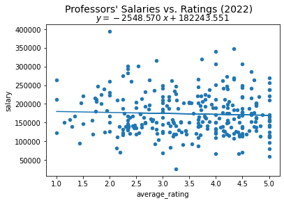

```python
from sklearn.linear_model import LinearRegression
import statsmodels.formula.api as smf
import numpy as np

data_of_interest = merged_df_prof[(merged_df_prof['salary_year']==2022) & (merged_df_prof['num_reviews'] > 2)]

# Fit a linear regression model to the data
model = smf.ols(formula='salary ~ average_rating', data=data_of_interest).fit()
print(model.summary())
print(f"\nExpected Salary = {model.params['average_rating']} * average_rating - {abs(model.params['Intercept'])}")


data_of_interest.plot(x="average_rating", y="salary", kind="scatter")

# Add trendline to the plot
z = np.polyfit(data_of_interest["average_rating"], data_of_interest["salary"], 1)
p = np.poly1d(z)
plt.plot(data_of_interest["average_rating"], p(data_of_interest["average_rating"]))
plt.title(f"$y={z[0]:0.3f}\;x{z[1]:+0.3f}$")
plt.xlabel("Average Rating")
plt.ylabel("Salary")
plt.suptitle("Professors' Salaries vs. Ratings (2022)", fontsize=14)
```

Interestingly enough, there is no correlation at all between salary and professor's ratings on planetterp.com. As seen in the results, there is a p-value associated with the independent variable 'average_rating.' This p-value represents the likelihood that the coefficient for this variable is 0. The null hypothesis is that the coefficient is equal to 0; the alternative hypothesis is that this coefficient is different from 0. Since it is a very high p-value (0.433), there is not enough evidence to reject the null hypothesis. In otherwords, we cannot claim that the coefficient is different from 0, and if that is the case, there is essentially no linear relationship between salary and average rating. This conclusion can also be reached by looking at the R-squared value, which is 0.002. This means that 0.2% of the variation in salary can be explained by average rating, which is a very low proportion.

Could there possibly be a linear relationship between rating and salary within a department? Unfortunately, there are not enough data points within most departments to run a linear regression analysis. To counter that, I will group by schools instead. As seen in previous graphs, schools tend to have similar distributions within them. We will only focus on three schools for now:

- ARHU (Arts and Humanities)
- BMGT (Business and Management)
- CMNS (Computer, Mathematical, and Natural Sciences)

ARHU and BMGT were selected because they repeatedly showed up throughout the analysis, and CMNS was added along beause it is one of the biggest schools in UMD.

#### ARHU Linear Regression Analysis

```
                            OLS Regression Results
==============================================================================
Dep. Variable:                 salary   R-squared:                       0.001
Model:                            OLS   Adj. R-squared:                 -0.026
Method:                 Least Squares   F-statistic:                   0.03273
Date:                Fri, 02 Dec 2022   Prob (F-statistic):              0.857
Time:                        21:24:15   Log-Likelihood:                -472.61
No. Observations:                  39   AIC:                             949.2
Df Residuals:                      37   BIC:                             952.5
Df Model:                           1
Covariance Type:            nonrobust
==================================================================================
                     coef    std err          t      P>|t|      [0.025      0.975]
----------------------------------------------------------------------------------
Intercept       1.355e+05   3.35e+04      4.047      0.000    6.77e+04    2.03e+05
average_rating -1511.7103   8355.333     -0.181      0.857   -1.84e+04    1.54e+04
==============================================================================
Omnibus:                        6.462   Durbin-Watson:                   2.140
Prob(Omnibus):                  0.040   Jarque-Bera (JB):                5.495
Skew:                           0.622   Prob(JB):                       0.0641
Kurtosis:                       4.354   Cond. No.                         19.5
==============================================================================

Notes:
[1] Standard Errors assume that the covariance matrix of the errors is correctly specified.

Expected Salary = -1511.7102910291305 * average_rating - 135467.4535099081
```

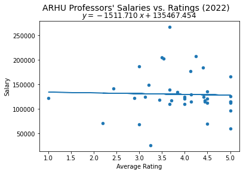

```python
data_of_interest = merged_df_prof[(merged_df_prof['salary_year']==2022) & (merged_df_prof['num_reviews'] > 2) & (merged_df_prof['department'].str.startswith("ARHU"))]

# Fit a linear regression model to the data
model = smf.ols(formula='salary ~ average_rating', data=data_of_interest).fit()
print(model.summary())
print(f"\nExpected Salary = {model.params['average_rating']} * average_rating - {abs(model.params['Intercept'])}")


data_of_interest.plot(x="average_rating", y="salary", kind="scatter")

# Add trendline to the plot
z = np.polyfit(data_of_interest["average_rating"], data_of_interest["salary"], 1)
p = np.poly1d(z)
plt.plot(data_of_interest["average_rating"], p(data_of_interest["average_rating"]))
plt.title(f"$y={z[0]:0.3f}\;x{z[1]:+0.3f}$")
plt.xlabel("Average Rating")
plt.ylabel("Salary")
plt.suptitle("ARHU Professors' Salaries vs. Ratings (2022)", fontsize=14)
```

In the above display, we see the results of the running the linear regression model on ARHU professors. Yet again, we see a very high p-value (0.857) for the slope coefficient, meaning that there is not enough evidence to believe the coefficient is different from 0. The R-squared value (0.001) is also very small.

```
                            OLS Regression Results
==============================================================================
Dep. Variable:                 salary   R-squared:                       0.016
Model:                            OLS   Adj. R-squared:                  0.008
Method:                 Least Squares   F-statistic:                     1.965
Date:                Fri, 02 Dec 2022   Prob (F-statistic):              0.164
Time:                        21:30:20   Log-Likelihood:                -1468.4
No. Observations:                 120   AIC:                             2941.
Df Residuals:                     118   BIC:                             2946.
Df Model:                           1
Covariance Type:            nonrobust
==================================================================================
                     coef    std err          t      P>|t|      [0.025      0.975]
----------------------------------------------------------------------------------
Intercept       1.469e+05   1.59e+04      9.227      0.000    1.15e+05    1.78e+05
average_rating  6036.5941   4306.370      1.402      0.164   -2491.191    1.46e+04
==============================================================================
Omnibus:                       14.538   Durbin-Watson:                   1.991
Prob(Omnibus):                  0.001   Jarque-Bera (JB):               16.682
Skew:                           0.746   Prob(JB):                     0.000239
Kurtosis:                       4.055   Cond. No.                         13.7
==============================================================================

Notes:
[1] Standard Errors assume that the covariance matrix of the errors is correctly specified.

Expected Salary = 6036.5941444691325 * average_rating - 146914.2432309923
```

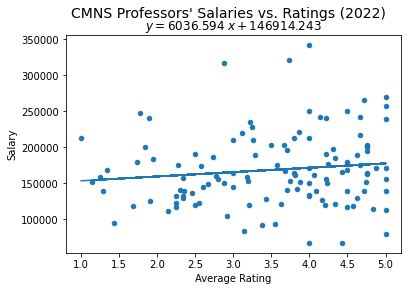

```python
data_of_interest = merged_df_prof[(merged_df_prof['salary_year']==2022) & (merged_df_prof['num_reviews'] > 2) & (merged_df_prof['department'].str.startswith("CMNS"))]

# Fit a linear regression model to the data
model = smf.ols(formula='salary ~ average_rating', data=data_of_interest).fit()
print(model.summary())
print(f"\nExpected Salary = {model.params['average_rating']} * average_rating - {abs(model.params['Intercept'])}")


data_of_interest.plot(x="average_rating", y="salary", kind="scatter")

# Add trendline to the plot
z = np.polyfit(data_of_interest["average_rating"], data_of_interest["salary"], 1)
p = np.poly1d(z)
plt.plot(data_of_interest["average_rating"], p(data_of_interest["average_rating"]))
plt.xlabel("Average Rating")
plt.ylabel("Salary")
plt.title(f"$y={z[0]:0.3f}\;x{z[1]:+0.3f}$")
plt.suptitle("CMNS Professors' Salaries vs. Ratings (2022)", fontsize=14)
```

Above are the results for the CMNS department. Yet again, we are faced with a high p-value (0.164) and low R-sqaured value (0.016).

```
                            OLS Regression Results
==============================================================================
Dep. Variable:                 salary   R-squared:                       0.005
Model:                            OLS   Adj. R-squared:                 -0.105
Method:                 Least Squares   F-statistic:                   0.04656
Date:                Fri, 02 Dec 2022   Prob (F-statistic):              0.834
Time:                        21:31:11   Log-Likelihood:                -136.43
No. Observations:                  11   AIC:                             276.9
Df Residuals:                       9   BIC:                             277.7
Df Model:                           1
Covariance Type:            nonrobust
==================================================================================
                     coef    std err          t      P>|t|      [0.025      0.975]
----------------------------------------------------------------------------------
Intercept       2.725e+05   6.35e+04      4.290      0.002    1.29e+05    4.16e+05
average_rating -3961.7355   1.84e+04     -0.216      0.834   -4.55e+04    3.76e+04
==============================================================================
Omnibus:                        2.579   Durbin-Watson:                   1.614
Prob(Omnibus):                  0.275   Jarque-Bera (JB):                0.384
Skew:                           0.203   Prob(JB):                        0.825
Kurtosis:                       3.821   Cond. No.                         12.0
==============================================================================

Notes:
[1] Standard Errors assume that the covariance matrix of the errors is correctly specified.

Expected Salary = -3961.735492018339 * average_rating - 272486.3643930808
```

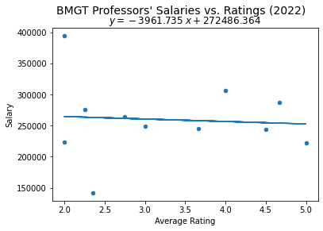

```python
data_of_interest = merged_df_prof[(merged_df_prof['salary_year']==2022) & (merged_df_prof['num_reviews'] > 2) & (merged_df_prof['department'].str.startswith("BMGT"))]

# Fit a linear regression model to the data
model = smf.ols(formula='salary ~ average_rating', data=data_of_interest).fit()
print(model.summary())
print(f"\nExpected Salary = {model.params['average_rating']} * average_rating - {abs(model.params['Intercept'])}")


data_of_interest.plot(x="average_rating", y="salary", kind="scatter")

# Add trendline to the plot
z = np.polyfit(data_of_interest["average_rating"], data_of_interest["salary"], 1)
p = np.poly1d(z)
plt.xlabel("Average Rating")
plt.ylabel("Salary")
plt.plot(data_of_interest["average_rating"], p(data_of_interest["average_rating"]))
plt.title(f"$y={z[0]:0.3f}\;x{z[1]:+0.3f}$")
plt.suptitle("BMGT Professors' Salaries vs. Ratings (2022)", fontsize=14)
```

These are results for running the analysis on the BMGT school. The p-value is 0.834 and the R-squared value 0.005, both of which suggest that there is no linear relationship.

In the end, after looking at the entire data set and breaking it down into smaller schools, there appears to be no linear correlation between professor's salaries and their ratings on plannetterp.com.

# Conclusions

I pulled data from both planetterp.com and the Diamondback newspaper to extract various data about professors, including students' opinions on them as well as their university salary. I analyzed the data individually and then finally pieced them together to investigate whether there is a relationship between salary and ratings. The process required a lot of manipulation of the data to reduce the noise and to fill in empty rows. For example, some professors in the planetterp.com database only taught during past years, so their department and salary had to be extracted from older data. Another challenge was that the Diamondback contains salary data for all faculty members, meanwhile planetterp.com contains data on all instructors. It would be unfair to compare a professor to a lecturer due to their different responsibilities and expected componesation, so I tried to control for this by reducing the scope to focus on those with the 'Professor' titleship. The planetterp.com data also needed to be treated with caution because some faculty members would only have 1 or 2 anonymous review(s) under their name. With so few reviews, it is easy to get biased results, so such data entries were excluded from the analysis.

In the end, I managed to answer several questions:

#### What does the distribution of planetterp.com ratings look like?

On the planetterp.com website, there are an inflated number of 5 star ratings such that the median rating is 4.1. If you were to account for only professors, this drops down to 3.84, and if you were to filter out professors with only 1 or 2 reviews, this leaves us with a median of 3.67. Generally, the distribution is left-skewed. There are more professors with high ratings than lower ratings, but there is still a significant number who have an average rating of 2 or below.

#### How do the distribution of ratings differ by department?

I selected to only view the departments which had more than 10 professors with ratings. There were no two department which were exactly alike in their distribution. Some tended to have very high ratings such as ARHU , while some had low like DO&IT. Some departments had a lot of variation, some had very little. If we were to look at the schools however, there were some observable patterns. The ARHU school tends to have higher ratings, while the CMNS school tends to have departments right at the average with a very wide distribution.

Two particular departments stood out: BMGT-Decision, Operations & Information Technologies and ARHU-School of Languages, Literatures, and Cultures. After running a few statistical tests, these were picked out to be most likely different from each other, but there is still not enough data to confidently say it. In the future, it may be in UMD's interest to particularly pick out why so many professors in the BMGT school are suffering from low ratings on planetterp.com. Perhaps this will give some insight on hiring priorities or curricumulum structure.

#### What does the distribution of salaries look like?

The distribution for all UMD faculty is extremely right-skewed, similar to a power law distribution. It comes as no surprise that the president and the head sport coaches are some of the highest paid individuals in the university. For professors, the distribution is much more symmetrical, with a median salary of \$155,692.77. There is still an interquartile range of \$91,224.15, which is quite large.

#### What does the distribution of salaries look like by department?

I selected to view only departments with more than 17 professors. Similarly, many of the departments had diffferent averages and spread. Interestingly, DO&IT, which have some of the lower professor ratings, has a higher median salary than any of the other departments. Meanwhile, the ARHU schools tend to have higher professor ratings but earn below average salaries. Not to mention, the ARHU had the least variation in salary compared to other departments.

#### Is there a linear relationship between salary and planetterp.com rating?

It may wishful thinking that perhaps good professors are compensated with higher salaries, or perhaps higher salaries could inspire professors to meet students' expectations. Regardless of these what-if's, they beg of question of whether there is any correlation between salary and professor rating, and the answer is no. The p-value for the linear regression slope coefficient is too large to conclude that there is a significant relationship. The results are the same whether we look at all the data or separate it out by school.

It is unfortunate that 'good' professors are not rewarded with compensation that reflects their ability to teach. It would be interesting to experiment whether money could provide a strong enough incentive to improve their reviews.

In the future, more analysis can be done on the data that has not been touched at all in this tutorial. For the sake of remaining consistent, I only focused on professors, but it is hardly the truth that everyone who teaches a class is a professor. Many are lecturers, associate professors, assistant professors, emeritus professors, etc. A thorough analysis that takes titles into consideration could potentially open up more speculation on how we can restructure the education at UMD.